# miPEP_H_16S

Harriet

03/02/2021

Note: “root” samples (roots, rhizoplane and close rhizosphere) and “soil” samples (distant rhizosphere and unplanted soils) shouldn’t be analyzed together. The DNA of these 2 types of samples was not extracted in the same manner: Nucleospin Plant Kit and Griffiths protocole, respectively. Moreover, soil samples 16S and ITS were quantified by qPCR with the addition of BSA (0,67mg/mL), which was not added for the root samples. There should be 96 samples = 8 plants (RACINE) “ROOTS and close rhizosphere” * 4 conditions (miPEPa,b,c, control) + 8 soils (SOL) “distant rhizosphere” + 8 sols nus (SOL.NU) “unplanted soils”.

Loading all the necessary packages and calling my files: I’m using the otu_table_filtered.biom file which is the result of pre-processing (quality control, filtering…) done my the automatic pipeline. ASVs found in less than 3 samples are discarded.

```r
library(phyloseq)
library(data.table)
library(vegan)
```

```r
library(ggplot2)
library(readxl)

biom_file<-import_biom("~/metabarcoding_miPEP_mutants/16S/16S/plaque2/export/otu_tables/otu_table_filtered.biom", "~/metabarcoding_miPEP_mutants/16S/16S/plaque2/export/tree/tree.fasttree", "~/metabarcoding_miPEP_mutants/16S/16S/plaque2/export/otu_tables/otus.fasta", parseFunction=parse_taxonomy_greengenes)
biom_file
```

```
## phyloseq-class experiment-level object
## otu_table()   OTU Table:         [ 5406 taxa and 96 samples ]
## tax_table()   Taxonomy Table:    [ 5406 taxa by 12 taxonomic ranks ]
## phy_tree()    Phylogenetic Tree: [ 5406 tips and 5395 internal nodes ]
## refseq()      DNAStringSet:      [ 5406 reference sequences ]
```

A data frame is created from the mapping_file, which contains all information concerning each sample. Each row corresponds to a sample and is named in consequence. Merge the biom file and the metadata into one phyloseq object.

```r
sample<- data.frame(fread("~/metabarcoding_miPEP_mutants/16S/16S/plaque2/export/mapping_file.tsv", sep="\t"), check.names=F)
head(sample)
```

```
##   #SampleID Compartment    Type      Treatment
## 1       aR1      RACINE miPEP-A RACINE-miPEP-A
## 2       aR2      RACINE miPEP-A RACINE-miPEP-A
## 3       aR3      RACINE miPEP-A RACINE-miPEP-A
## 4       aR4      RACINE miPEP-A RACINE-miPEP-A
## 5       aR5      RACINE miPEP-A RACINE-miPEP-A
## 6       aR6      RACINE miPEP-A RACINE-miPEP-A
```

```r
sample=sample_data(sample)

rownames(sample)<-sample$`#SampleID`
merge<-merge_phyloseq(biom_file,sample)
merge
```

```
## phyloseq-class experiment-level object
## otu_table()   OTU Table:         [ 5406 taxa and 96 samples ]
## sample_data() Sample Data:       [ 96 samples by 4 sample variables ]
## tax_table()   Taxonomy Table:    [ 5406 taxa by 12 taxonomic ranks ]
## phy_tree()    Phylogenetic Tree: [ 5406 tips and 5395 internal nodes ]
## refseq()      DNAStringSet:      [ 5406 reference sequences ]
```

Extract the OTU and taxa table

```r
tax_table = tax_table(merge)
head(tax_table)
```

```
## Taxonomy Table:     [6 taxa by 12 taxonomic ranks]:
##      Kingdom    Phylum          Class             Order
## 4810 "Bacteria" "Cyanobacteria" "ML635J-21"       "ML635J-21CL"
## 664  "Bacteria" "Cyanobacteria" "ML635J-21"       "ML635J-21CL"
## 4884 "Bacteria" "Cyanobacteria" "ML635J-21"       "ML635J-21CL"
## 3285 "Bacteria" "Cyanobacteria" "ML635J-21"       "ML635J-21CL"
## 503  "Bacteria" "Cyanobacteria" "Melainabacteria" "Vampirovibrionales"
## 3954 "Bacteria" "Cyanobacteria" "Melainabacteria" "Vampirovibrionales"
##      Family                 Genus                  Rank7 Rank6 Rank4 Rank5
## 4810 "ML635J-21CL"          "ML635J-21CL"          NA    NA    NA    NA
## 664  "ML635J-21CL"          "ML635J-21CL"          NA    NA    NA    NA
## 4884 "ML635J-21CL"          "ML635J-21CL"          NA    NA    NA    NA
## 3285 "ML635J-21CL"          "ML635J-21CL"          NA    NA    NA    NA
## 503  "VampirovibrionalesOR" "VampirovibrionalesOR" NA    NA    NA    NA
## 3954 "VampirovibrionalesOR" "VampirovibrionalesOR" NA    NA    NA    NA
##      Rank3 Rank2
## 4810 NA    NA
## 664  NA    NA
## 4884 NA    NA
## 3285 NA    NA
## 503  NA    NA
## 3954 NA    NA
```

```r
#remplacer les noms de colonnes Rank1, rank2.. par les noms de taxons
colnames(tax_table) = c("Kingdom", "Phylum", "Class", "Order", "Family", "Genus", "Species", "rank8", "rank9", "rank10", "rank11","rank12")
head(tax_table)
```

```
## Taxonomy Table:     [6 taxa by 12 taxonomic ranks]:
##      Kingdom    Phylum          Class             Order
## 4810 "Bacteria" "Cyanobacteria" "ML635J-21"       "ML635J-21CL"
## 664  "Bacteria" "Cyanobacteria" "ML635J-21"       "ML635J-21CL"
## 4884 "Bacteria" "Cyanobacteria" "ML635J-21"       "ML635J-21CL"
## 3285 "Bacteria" "Cyanobacteria" "ML635J-21"       "ML635J-21CL"
## 503  "Bacteria" "Cyanobacteria" "Melainabacteria" "Vampirovibrionales"
## 3954 "Bacteria" "Cyanobacteria" "Melainabacteria" "Vampirovibrionales"
##      Family                 Genus                  Species rank8 rank9 rank10
## 4810 "ML635J-21CL"          "ML635J-21CL"          NA      NA    NA    NA
## 664  "ML635J-21CL"          "ML635J-21CL"          NA      NA    NA    NA
## 4884 "ML635J-21CL"          "ML635J-21CL"          NA      NA    NA    NA
## 3285 "ML635J-21CL"          "ML635J-21CL"          NA      NA    NA    NA
## 503  "VampirovibrionalesOR" "VampirovibrionalesOR" NA      NA    NA    NA
## 3954 "VampirovibrionalesOR" "VampirovibrionalesOR" NA      NA    NA    NA
##      rank11 rank12
## 4810 NA     NA
## 664  NA     NA
## 4884 NA     NA
## 3285 NA     NA
## 503  NA     NA
## 3954 NA     NA
```

```r
#write.table(tax_table, "tax_table.txt")

OTU_table = otu_table(merge)
#write.table(OTU_table, "OTU_table.txt")
```

Count the number of sequences in each samples. raremax gives the sample with the lowest sequence number (usefull if rarefying)

```r
Seq<-sample_sums(merge)
Seq
```

```
##     aR1     aR2     aR3     aR4     aR5     aR6     aR7     aR8     aS1     aS2
##   15446   14021   15441   25652   18433   11822   18796   12022   39383   39779
##     aS3     aS4     aS5     aS6     aS7     aS8    aSN1    aSN2    aSN3    aSN4
##   29420   38315   12746   16912   10923   25975   20329   13868   33127   12771
##    aSN5    aSN6    aSN7    aSN8     bR1     bR2     bR3     bR4     bR5     bR6
##   26004   27693   25693   28211   21734   19785   16065   21339   14348   12637
##     bR7     bR8     bS1     bS2     bS3     bS4     bS5     bS6     bS7     bS8
##   18313   25908   37596   42011   43995   52693   44306   33607   63633   33156
##    bSN1    bSN2    bSN3    bSN4    bSN5    bSN6    bSN7    bSN8     cR1     cR2
##   55827   62457   47426   63641   35776   36873   39402   56007   19215   15048
##     cR3     cR4     cR5     cR6     cR7     cR8     cS1     cS2     cS3     cS4
##   19771   12828   17636   23127    7676   22536   42750   26320   47879   26752
##     cS5     cS6     cS7     cS8    cSN1    cSN2    cSN3    cSN4    cSN5    cSN6
##   44924   52692   36460   48628   36294   36287   37994   54383   39475   29279
##    cSN7    cSN8  ctrlR1  ctrlR2  ctrlR3  ctrlR4  ctrlR5  ctrlR6  ctrlR7  ctrlR8
##   51566   28087   10892   13223   14314   22500   12384   11471   19417    9385
##  ctrlS1  ctrlS2  ctrlS3  ctrlS4  ctrlS5  ctrlS6  ctrlS7  ctrlS8 ctrlSN1 ctrlSN2
##   38457   50314   35632   48535   28619   37237   19258   44706   34546   18967
## ctrlSN3 ctrlSN4 ctrlSN5 ctrlSN6 ctrlSN7 ctrlSN8
##   40268   36306   39396   43697   32731   44883
```

```r
#write.table(Seq, "sequences.txt")

min(Seq)
```

```
## [1] 7676
```

Keep ASVs that are at least present once in three samples.

```r
phylo_filtered = filter_taxa(merge, function(x) sum(x >= 1)>= (3), TRUE)
OTU_table_phylo_filtered = otu_table(phylo_filtered)
#write.table(OTU_table_phylo_filtered, "OTU_table_phylo_filtered.txt")
tax_table_phylo_filtered = tax_table(phylo_filtered)
#write.table(tax_table_phylo_filtered, "tax_table_phylo_filtered.txt")
```

After this filtration, you can lose a lot of ASVs (=taxa), but don’t lose so much sequences. You can check that by counting them again : here we have lost 35792 sequences and 3353 bacterial taxa.

```r
Seq_filtered<-sample_sums(phylo_filtered)
Seq_filtered
```

```
##     aR1     aR2     aR3     aR4     aR5     aR6     aR7     aR8     aS1     aS2
##   15375   13940   15288   23872   17812   11732   18478   11919   38855   39346
##     aS3     aS4     aS5     aS6     aS7     aS8    aSN1    aSN2    aSN3    aSN4
##   29228   35235   12685   16814   10865   25662   20207   13824   32926   12717
##    aSN5    aSN6    aSN7    aSN8     bR1     bR2     bR3     bR4     bR5     bR6
##   25858   27561   25608   28015   21457   19552   15933   20960   14212   12508
##     bR7     bR8     bS1     bS2     bS3     bS4     bS5     bS6     bS7     bS8
##   18117   25411   37208   41700   43607   51649   43878   33341   62772   32908
##    bSN1    bSN2    bSN3    bSN4    bSN5    bSN6    bSN7    bSN8     cR1     cR2
##   55126   61474   47092   62515   35530   36473   39226   55114   18966   14976
##     cR3     cR4     cR5     cR6     cR7     cR8     cS1     cS2     cS3     cS4
##   19354   12746   17336   22961    7311   22209   42391   26185   47212   26631
##     cS5     cS6     cS7     cS8    cSN1    cSN2    cSN3    cSN4    cSN5    cSN6
##   44373   51906   36139   48081   36106   36106   37851   53785   39330   29149
##    cSN7    cSN8  ctrlR1  ctrlR2  ctrlR3  ctrlR4  ctrlR5  ctrlR6  ctrlR7  ctrlR8
##   51093   27845   10800   13056   14205   22195   12156   11390   18940    9134
##  ctrlS1  ctrlS2  ctrlS3  ctrlS4  ctrlS5  ctrlS6  ctrlS7  ctrlS8 ctrlSN1 ctrlSN2
##   38087   49762   35258   47759   28263   36980   19027   43787   34308   18772
## ctrlSN3 ctrlSN4 ctrlSN5 ctrlSN6 ctrlSN7 ctrlSN8
##   39538   36107   39162   43402   32564   43991
```

```r
#write.table(Seq_filtered, "sequences_filtered.txt")
```

Have a look at your sequencing depth: do all samples reach a plateau? At which sample size?

```r
#remotes::install_github("mahendra-mariadassou/phyloseq-extended", ref = "dev")
library(phyloseq.extended)
p<-ggrare(phylo_filtered, step=100, color = "Compartment", label = "X.SampleID", se = FALSE)
```

[output not shown]

[output not shown]

[output cut: 28 more lines]

[output not shown]

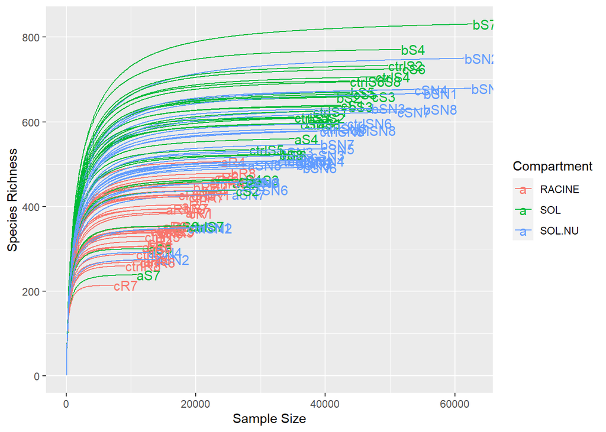

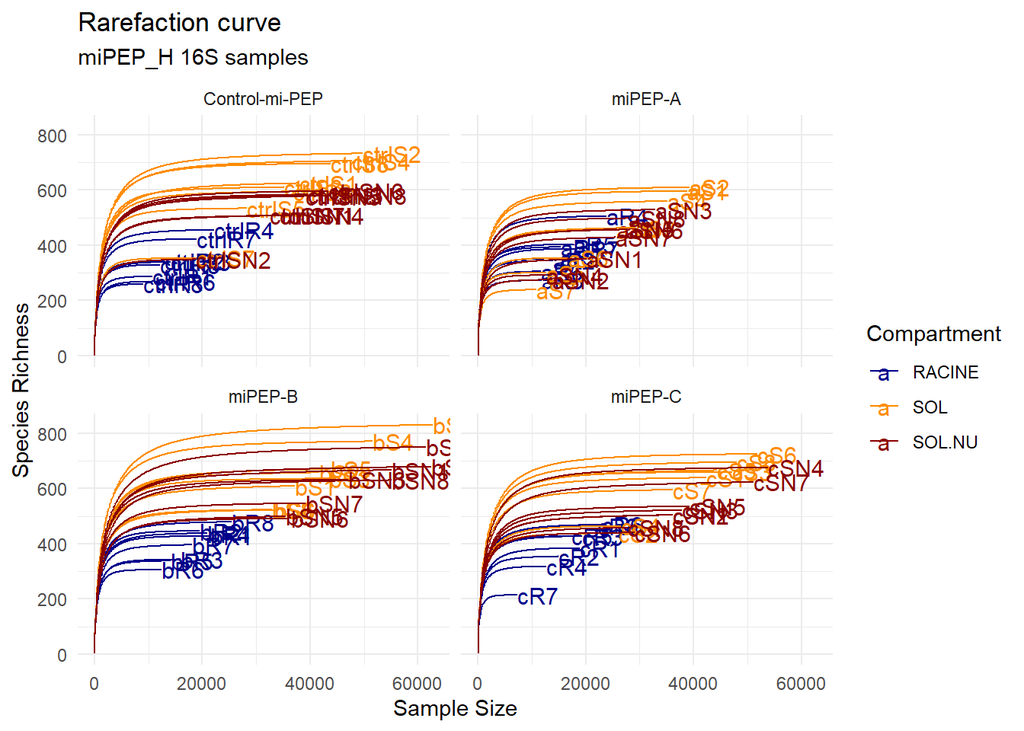

```r
p<-p + labs(title="Rarefaction curve", subtitle =  "miPEP_H 16S samples")
p<-p+scale_color_manual(values = c("dark blue", "dark orange", "dark red"))
p<-p+theme_minimal()
p <- p + facet_wrap(~Type)
p
```

16S/ITS sequencing doesn’t allow for “real” quantitative data. To overcome this, 16S and ITS genes were quantified by qPCR, along with a standard curve, to evaluate the “absolute” number of copies of 16S and ITS in each sample. The mean Ct was converted to a number of copies, by using the equation of the standard curve. For ITS, a ratio of fungal ITS/non-fungal ITS was applied to each sample, corresponding to the sequences counted during sequencing (=fungal ASVs/total ITS ASVs). The number of copies was used to replace the total sum of 16S ASVs, per sample, and each ASV was re-caculated as a number of copies. The resulting “absolute” abundance ASV table needs to be imported into R and processed into a new phyloseq object. 1) Export phylo_filtered OTU table 2) Open OTU table with Excel - align samples with their correct column - add “calculs” sheet and add “Samples” line and a “ASV ID” column - line 2 = number of ITS copies/sample (final number of copies, after multplied by ITS ratio=nb fungal ITS/total nb of ITS) - CALCULATION: to repeat for each sample: ASV = nb seq ASV * nb copies ITS / sum sequences in that sample 3) Add a spread sheed to the Excel file “quant abs” -copy/paste the “calculs” sheet with just the data “1,2,3” -delete the line 2 (with the number of copies) -save as an Excel file (.xlsx) 4) Put all the cells into format “Number” with no decimals and export the active sheet as .txt (Tabulation) 5) Go to Galaxy.genouest.org and upload your .txt file, then search for “convert between BIOM table formats” input =.txt and output = BIOM1 file “OTU TABLE”. change nothing else 6) Dowload the biom file and import to R

```r
otu_biom <- import_biom("~/metabarcoding_miPEP_mutants/16S/16S/plaque2/otu_table_absolute_16S.biom1")

tax <- tax_table(tax_table_phylo_filtered) #taxa hasn't changed

samples <- sample_data(merge) #use your metadata from before

phylo_abs_16S <- merge_phyloseq(tax,otu_biom,samples)

#Before continuing, we must discard the sample cR7 from the root samples, which has much less copies.
Sample_toRemove <- c("X.SampleID"="cR7")
subset_samples(phylo_abs_16S, X.SampleID %in% Sample_toRemove)
```

```
## phyloseq-class experiment-level object
## otu_table()   OTU Table:         [ 2053 taxa and 1 samples ]
## sample_data() Sample Data:       [ 1 samples by 4 sample variables ]
## tax_table()   Taxonomy Table:    [ 2053 taxa by 12 taxonomic ranks ]
```

```r
subset_samples(phylo_abs_16S, !(X.SampleID %in% Sample_toRemove))
```

```
## phyloseq-class experiment-level object
## otu_table()   OTU Table:         [ 2053 taxa and 95 samples ]
## sample_data() Sample Data:       [ 95 samples by 4 sample variables ]
## tax_table()   Taxonomy Table:    [ 2053 taxa by 12 taxonomic ranks ]
```

```r
phylo_abs_16S <- subset_samples(phylo_abs_16S, !(X.SampleID %in% Sample_toRemove))
phylo_abs_16S #should have only 95 samples now (-cR7)
```

```
## phyloseq-class experiment-level object
## otu_table()   OTU Table:         [ 2053 taxa and 95 samples ]
## sample_data() Sample Data:       [ 95 samples by 4 sample variables ]
## tax_table()   Taxonomy Table:    [ 2053 taxa by 12 taxonomic ranks ]
```

```r
OTU_table = otu_table(phylo_abs_16S)
samples_final <- sample_data(phylo_abs_16S)

phylo_abs_16S <- merge_phyloseq(tax_table,OTU_table,samples_final)
```

```r
correct.order <- c("miPEP-A", "miPEP-B", "miPEP-C", "Control-mi-PEP")
sample_data(phylo_abs_16S)$Type <- factor(sample_data(phylo_abs_16S)$Type, levels = correct.order)
levels(get_variable(phylo_abs_16S, "Type")) #mettre dans le bon ordre
```

```
## [1] "miPEP-A"        "miPEP-B"        "miPEP-C"        "Control-mi-PEP"
```

```r
phylo_roots <- subset_samples(phylo_abs_16S, Compartment=="RACINE")
phylo_soil <- subset_samples(phylo_abs_16S, Compartment=="SOL")
phylo_unplanted <- subset_samples(phylo_abs_16S, Compartment=="SOL.NU")
```

Venn-Diagrams to show shared ASVs between treatments: limited to 5

```r
# 1) Use a phyloseq object with 1 variable left, you could have to start with phylo_roots, for ex
phylo_roots
```

```
## phyloseq-class experiment-level object
## otu_table()   OTU Table:         [ 2053 taxa and 31 samples ]
## sample_data() Sample Data:       [ 31 samples by 4 sample variables ]
## tax_table()   Taxonomy Table:    [ 2053 taxa by 12 taxonomic ranks ]
```

```r
# 2) The next steps are performed on the means of each treatment, so merge treated-samples
merge_phyloseq_subset<-merge_samples(phylo_roots,"Type")
# The Types will become numbers in the same order as in the phyloseq:
# 1=ago; 2=dcl; 3=hen; 4=RTL1; 5=RTL1myc and 6=WT

# 3) Create a table with a dataframe such as OTUs=columns and Type=rows
table<-t(merge_phyloseq_subset@otu_table@.Data)

# 4) Create a vector per Type to have the right format for Venn Diagram
cat_1 <- rownames(table)[which(table[,1]!=0)]
cat_2 <- rownames(table)[which(table[,2]!=0)]
cat_3 <- rownames(table)[which(table[,3]!=0)]
cat_4 <- rownames(table)[which(table[,4]!=0)]


# 5) These vectors need to be formatted into a list object
input <- list("miPEP-A"=cat_1,  "miPEP-B"=cat_2, "miPEP-C"=cat_3, "Control-mi-PEP"=cat_4)

library(VennDiagram)
```

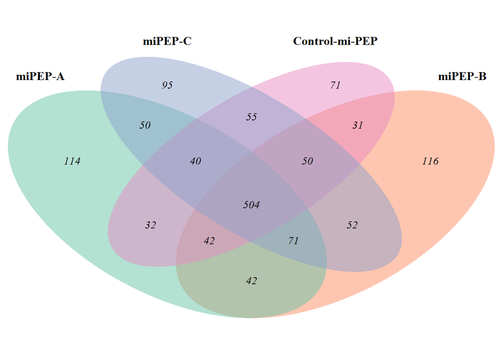

```r
library(gplots)
library(reshape2)
display_venn <- function(x, ...){
  library(VennDiagram)
  grid.newpage()
  venn_object <- venn.diagram(x, filename = NULL, ...)
  grid.draw(venn_object)
}
library(RColorBrewer)

myCol <- brewer.pal(4, "Set2") # the first number = nb of conditions
display_venn(input, lwd = 2, lty ='blank',  fill=myCol, # Numbers
        cex = .9,
        fontface = "italic",
        # Set names
        cat.cex = 1,
        cat.fontface = "bold",
        cat.default.pos = "outer")
```

```r
# 1) Use a phyloseq object with 1 variable left, you could have to start with phylo_roots, for ex
phylo_soil
```

```
## phyloseq-class experiment-level object
## otu_table()   OTU Table:         [ 2053 taxa and 32 samples ]
## sample_data() Sample Data:       [ 32 samples by 4 sample variables ]
## tax_table()   Taxonomy Table:    [ 2053 taxa by 12 taxonomic ranks ]
```

```r
# 2) The next steps are performed on the means of each treatment, so merge treated-samples
merge_phyloseq_subset<-merge_samples(phylo_soil,"Type")
```

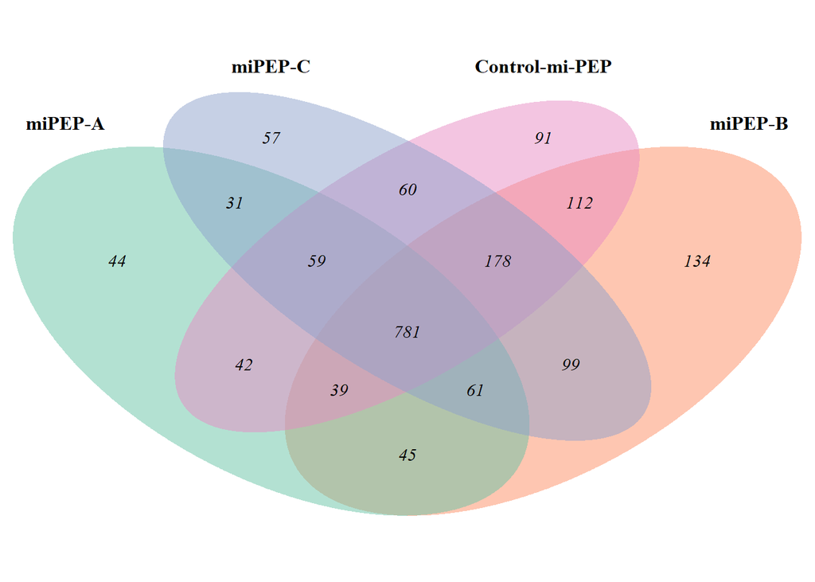

```r
# The Types will become numbers in the same order as in the phyloseq:
# 1=ago; 2=dcl; 3=hen; 4=RTL1; 5=RTL1myc and 6=WT

# 3) Create a table with a dataframe such as OTUs=columns and Type=rows
table<-t(merge_phyloseq_subset@otu_table@.Data)

# 4) Create a vector per Type to have the right format for Venn Diagram
cat_1 <- rownames(table)[which(table[,1]!=0)]
cat_2 <- rownames(table)[which(table[,2]!=0)]
cat_3 <- rownames(table)[which(table[,3]!=0)]
cat_4 <- rownames(table)[which(table[,4]!=0)]


# 5) These vectors need to be formatted into a list object
input <- list("miPEP-A"=cat_1,  "miPEP-B"=cat_2, "miPEP-C"=cat_3, "Control-mi-PEP"=cat_4)

library(VennDiagram)
library(gplots)
library(reshape2)
display_venn <- function(x, ...){
  library(VennDiagram)
  grid.newpage()
  venn_object <- venn.diagram(x, filename = NULL, ...)
  grid.draw(venn_object)
}
library(RColorBrewer)

myCol <- brewer.pal(4, "Set2") # the first number = nb of conditions
display_venn(input, lwd = 2, lty ='blank',  fill=myCol, # Numbers
        cex = .9,
        fontface = "italic",
        # Set names
        cat.cex = 1,
        cat.fontface = "bold",
        cat.default.pos = "outer")
```

```r
# 1) Use a phyloseq object with 1 variable left, you could have to start with phylo_roots, for ex
phylo_unplanted
```

```
## phyloseq-class experiment-level object
## otu_table()   OTU Table:         [ 2053 taxa and 32 samples ]
## sample_data() Sample Data:       [ 32 samples by 4 sample variables ]
## tax_table()   Taxonomy Table:    [ 2053 taxa by 12 taxonomic ranks ]
```

```r
# 2) The next steps are performed on the means of each treatment, so merge treated-samples
merge_phyloseq_subset<-merge_samples(phylo_unplanted,"Type")
```

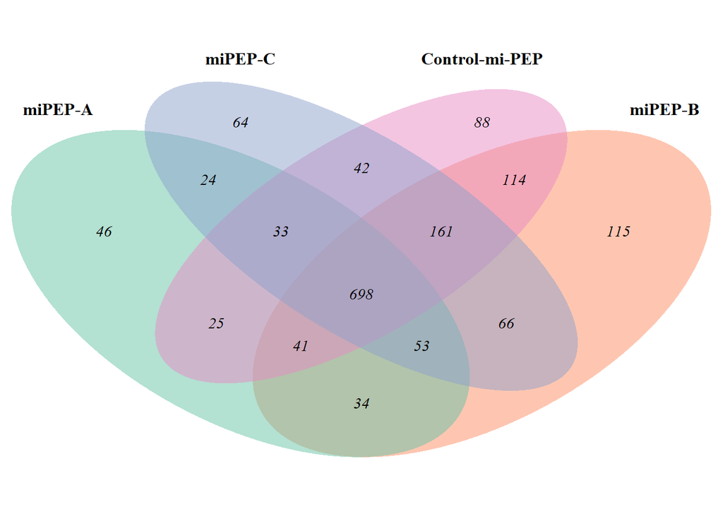

```r
# The Types will become numbers in the same order as in the phyloseq:
# 1=ago; 2=dcl; 3=hen; 4=RTL1; 5=RTL1myc and 6=WT

# 3) Create a table with a dataframe such as OTUs=columns and Type=rows
table<-t(merge_phyloseq_subset@otu_table@.Data)

# 4) Create a vector per Type to have the right format for Venn Diagram
cat_1 <- rownames(table)[which(table[,1]!=0)]
cat_2 <- rownames(table)[which(table[,2]!=0)]
cat_3 <- rownames(table)[which(table[,3]!=0)]
cat_4 <- rownames(table)[which(table[,4]!=0)]

# 5) These vectors need to be formatted into a list object
input <- list("miPEP-A"=cat_1,  "miPEP-B"=cat_2, "miPEP-C"=cat_3, "Control-mi-PEP"=cat_4)

library(VennDiagram)
library(gplots)
library(reshape2)
display_venn <- function(x, ...){
  library(VennDiagram)
  grid.newpage()
  venn_object <- venn.diagram(x, filename = NULL, ...)
  grid.draw(venn_object)
}
library(RColorBrewer)

myCol <- brewer.pal(4, "Set2") # the first number = nb of conditions
display_venn(input, lwd = 2, lty ='blank',  fill=myCol, # Numbers
        cex = .9,
        fontface = "italic",
        # Set names
        cat.cex = 1,
        cat.fontface = "bold",
        cat.default.pos = "outer")
```

Abundance plot in all samples

```r
library(microbiome)
library(dplyr)
```

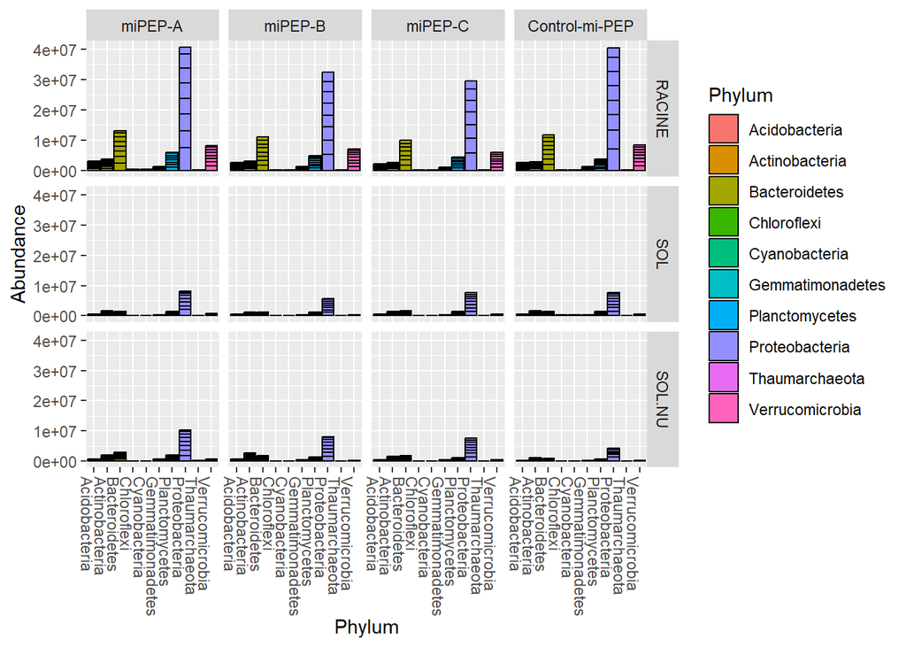

```r
pseq <- phylo_abs_16S %>% aggregate_taxa(level = "Phylum")
#ps1.com.fam <- microbiome::aggregate_top_taxa(pseq, "Phylum", top = 10)

ps1.com.fam <- names(sort(taxa_sums(pseq), decreasing = TRUE))[1:10]
ps1.com.fam <- prune_taxa(ps1.com.fam, pseq)

plot_bar(ps1.com.fam, "Phylum", fill="Phylum", facet_grid=Compartment~Type)
```

Abudance plots (top phyla & genera) in roots and close rhizosphere samples

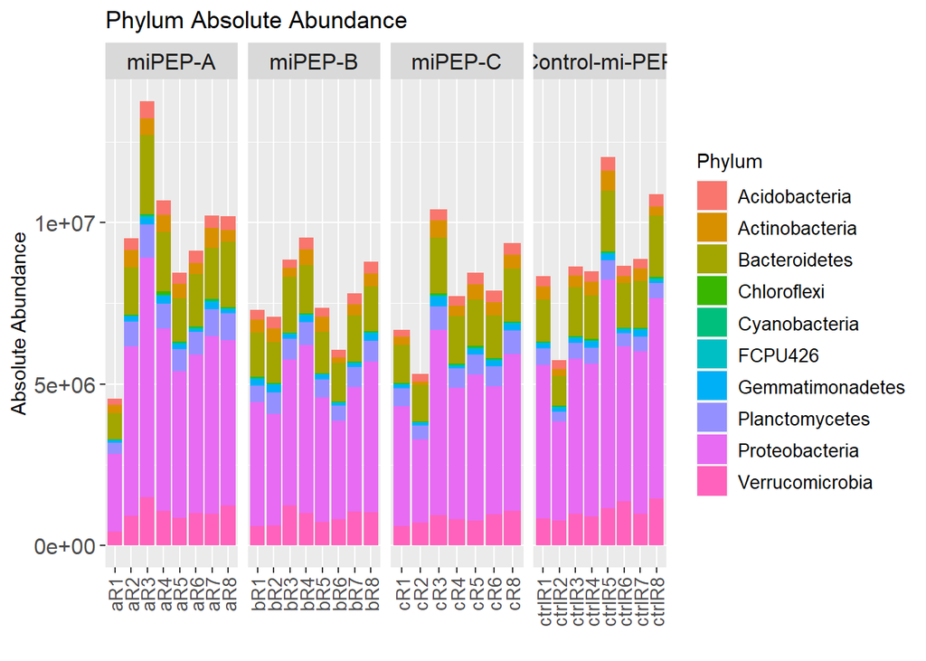

```r
pseq_roots <- phylo_roots %>% aggregate_taxa(level = "Phylum")
#ps1.com.fam_roots <- microbiome::aggregate_top_taxa(pseq_roots, "Phylum", top = 10)

ps1.com.fam_roots <- names(sort(taxa_sums(pseq_roots), decreasing = TRUE))[1:10]
ps1.com.fam_roots <- prune_taxa(ps1.com.fam_roots, pseq_roots)

taxa_abundance_table_phylum_roots <- psmelt(ps1.com.fam_roots)

StackedBarPlot_phylum <- taxa_abundance_table_phylum_roots %>%
  ggplot(aes(x =Sample, y = Abundance, fill = Phylum)) +
  geom_bar(stat = "identity") +
  labs(x = "",
       y = "Absolute Abundance",
       title = "Phylum Absolute Abundance") +
  facet_grid(~ Type, scales = "free") +
  theme(
    axis.text.x = element_text(size = 10, angle = 90, vjust = 0.5, hjust = 1),
    axis.text.y = element_text(size = 12),
    legend.text = element_text(size = 10),
    strip.text = element_text(size = 12)
  )
StackedBarPlot_phylum
```

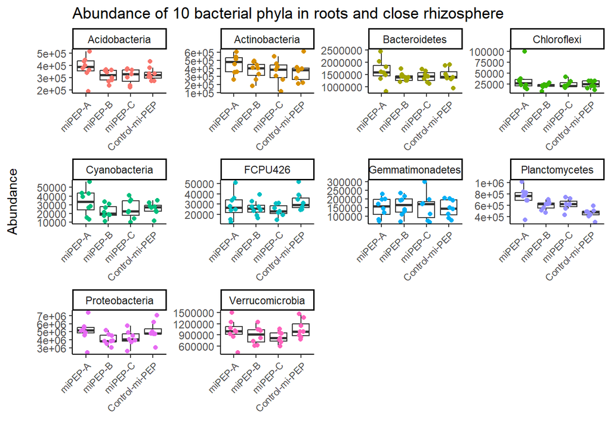

```r
#Create a boxplot to show differences in composition of each phylum per Type

phyloseq::psmelt(ps1.com.fam_roots) %>%
ggplot(data = ., aes(x = Type, y = Abundance)) +
  geom_boxplot(outlier.shape  = NA) +
  geom_jitter(aes(color = OTU), height = 0, width = .2) +
  labs(x = "", y = "Abundance\n") +
  facet_wrap(~ OTU, scales = "free") + guides(col = FALSE) +theme_classic() +theme(axis.text.x=element_text(size=8, angle=45,hjust=1)) + ggtitle(label = "Abundance of 10 bacterial phyla in roots and close rhizosphere")
```

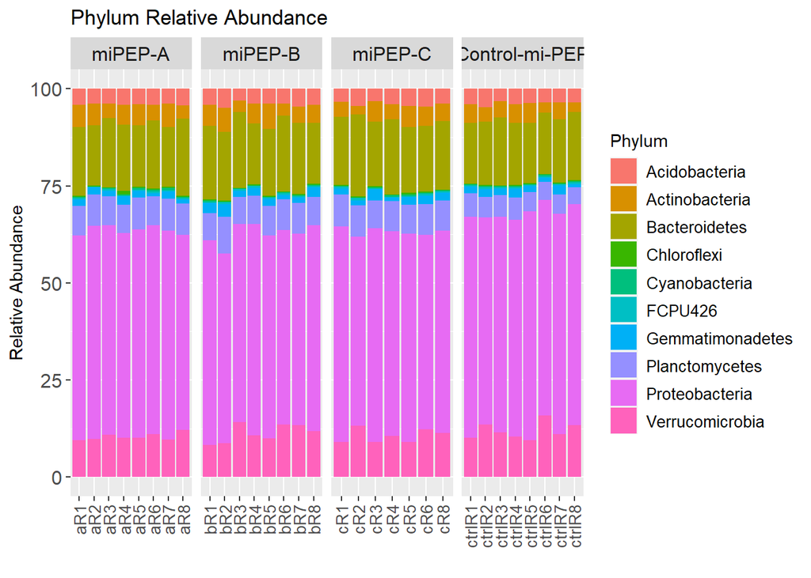

```r
# Transform Taxa counts to relative abundance for nice abundance plots
ps1_roots_phylum_relabun <- transform_sample_counts(ps1.com.fam_roots, function(OTU) OTU/sum(OTU) * 100)

taxa_abundance_table_phylum_roots_rel <- psmelt(ps1_roots_phylum_relabun)

StackedBarPlot_phylum_rel <- taxa_abundance_table_phylum_roots_rel %>%
  ggplot(aes(x =Sample, y = Abundance, fill = Phylum)) +
  geom_bar(stat = "identity") +
  labs(x = "",
       y = "Relative Abundance",
       title = "Phylum Relative Abundance") +
  facet_grid(~ Type, scales = "free") +
  theme(
    axis.text.x = element_text(size = 10, angle = 90, vjust = 0.5, hjust = 1),
    axis.text.y = element_text(size = 12),
    legend.text = element_text(size = 10),
    strip.text = element_text(size = 12)
  )
StackedBarPlot_phylum_rel
```

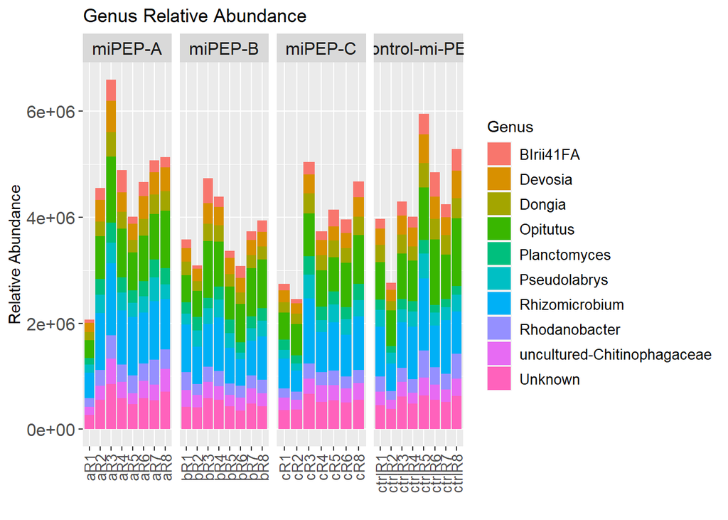

```r
############# GENUS ##############

pseq_roots_genus <- phylo_roots %>% aggregate_taxa(level = "Genus")
#ps1._roots_genus_top10 <- microbiome::aggregate_top_taxa(pseq_roots_genus, "Genus", top = 10)

ps1._roots_genus_top10 <- names(sort(taxa_sums(pseq_roots_genus), decreasing = TRUE))[1:10]
ps1._roots_genus_top10 <- prune_taxa(ps1._roots_genus_top10, pseq_roots_genus)

taxa_abundance_table_genus_roots <- psmelt(ps1._roots_genus_top10)

StackedBarPlot_genus_roots <- taxa_abundance_table_genus_roots %>%
  ggplot(aes(x =Sample, y = Abundance, fill = Genus)) +
  geom_bar(stat = "identity") +
  labs(x = "",
       y = "Relative Abundance",
       title = "Genus Relative Abundance") +
  facet_grid(~ Type, scales = "free") +
  theme(
    axis.text.x = element_text(size = 10, angle = 90, vjust = 0.5, hjust = 1),
    axis.text.y = element_text(size = 12),
    legend.text = element_text(size = 10),
    strip.text = element_text(size = 12)
  )

StackedBarPlot_genus_roots
```

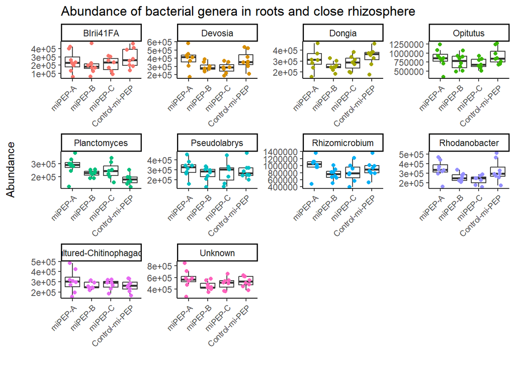

```r
#Boxplot

phyloseq::psmelt(ps1._roots_genus_top10) %>%
ggplot(data = ., aes(x = Type, y = Abundance)) +
  geom_boxplot(outlier.shape  = NA) +
  geom_jitter(aes(color = OTU), height = 0, width = .2) +
  labs(x = "", y = "Abundance\n") +
  facet_wrap(~ OTU, scales = "free")  + guides(col = FALSE) +theme_classic() +theme(axis.text.x=element_text(size=8, angle=45,hjust=1)) + ggtitle(label = "Abundance of bacterial genera in roots and close rhizosphere")
```

Abudance plots (top phyla & genera) in distant rhizosphere samples

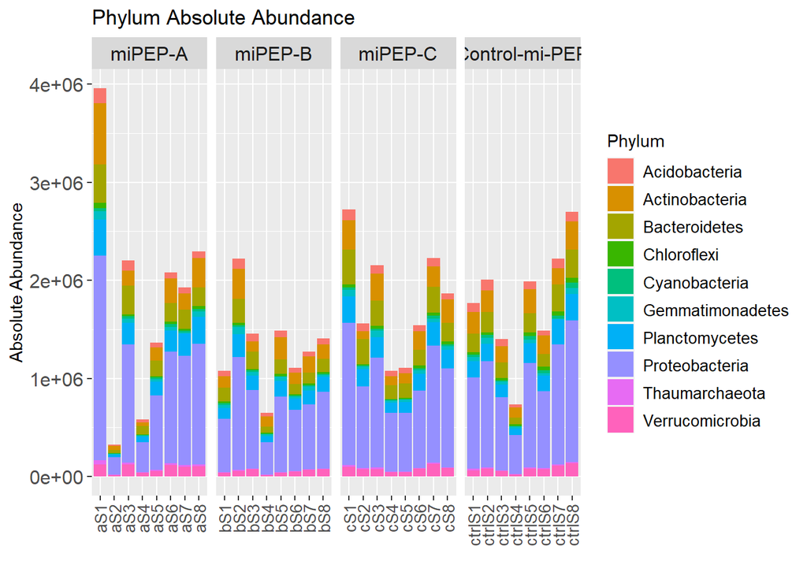

```r
pseq_soil <- phylo_soil %>% aggregate_taxa(level = "Phylum")
#ps1.com.fam_soil <- microbiome::aggregate_top_taxa(pseq_soil, "Phylum", top = 10)

ps1.com.fam_soil <- names(sort(taxa_sums(pseq_soil), decreasing = TRUE))[1:10]
ps1.com.fam_soil <- prune_taxa(ps1.com.fam_soil, pseq_soil)

taxa_abundance_table_phylum_soil <- psmelt(ps1.com.fam_soil)

StackedBarPlot_phylum <- taxa_abundance_table_phylum_soil %>%
  ggplot(aes(x =Sample, y = Abundance, fill = Phylum)) +
  geom_bar(stat = "identity") +
  labs(x = "",
       y = "Absolute Abundance",
       title = "Phylum Absolute Abundance") +
  facet_grid(~ Type, scales = "free") +
  theme(
    axis.text.x = element_text(size = 10, angle = 90, vjust = 0.5, hjust = 1),
    axis.text.y = element_text(size = 12),
    legend.text = element_text(size = 10),
    strip.text = element_text(size = 12)
  )
StackedBarPlot_phylum
```

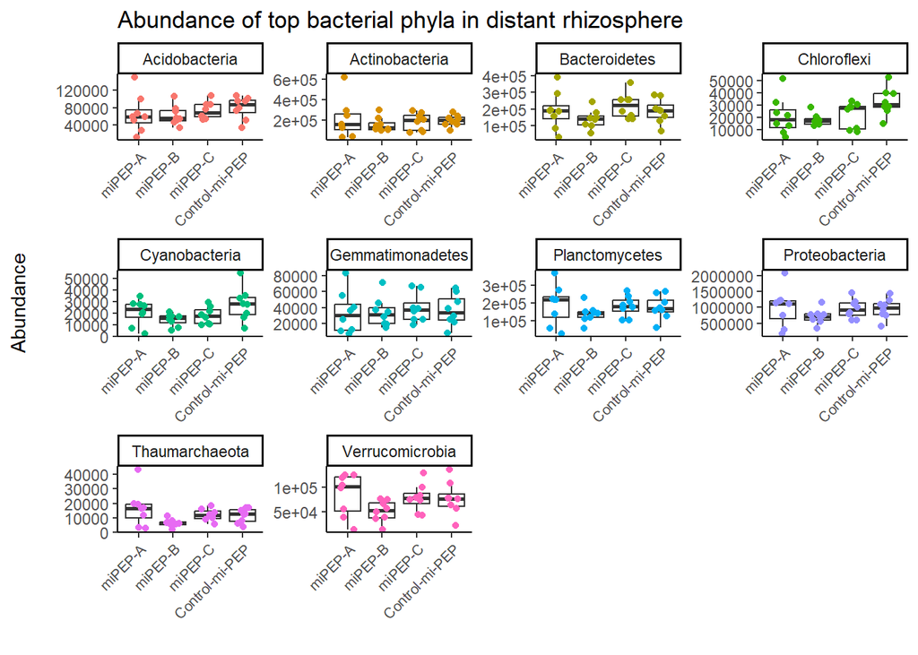

```r
#Create a boxplot to show differences in composition of each phylum per Type

phyloseq::psmelt(ps1.com.fam_soil) %>%
ggplot(data = ., aes(x = Type, y = Abundance)) +
  geom_boxplot(outlier.shape  = NA) +
  geom_jitter(aes(color = OTU), height = 0, width = .2) +
  labs(x = "", y = "Abundance\n") +
  facet_wrap(~ OTU, scales = "free") + guides(col = FALSE) +theme_classic() +theme(axis.text.x=element_text(size=8, angle=45,hjust=1)) + ggtitle(label = "Abundance of top bacterial phyla in distant rhizosphere")
```

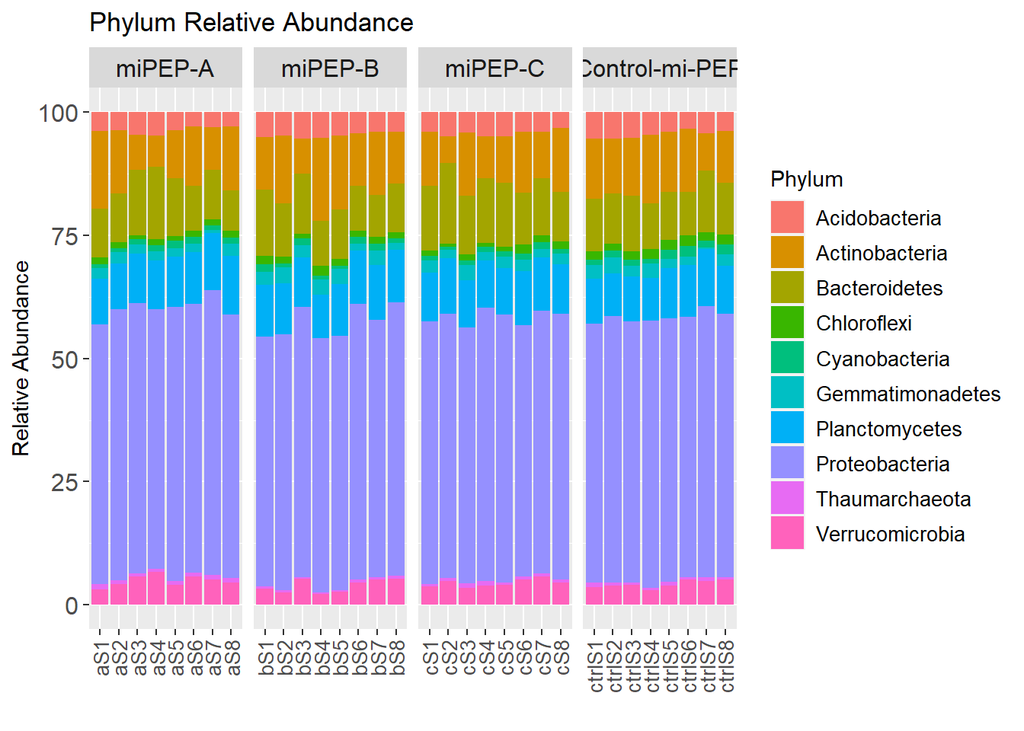

```r
# Transform Taxa counts to relative abundance for nice abundance plots
ps1_soil_phylum_relabun <- transform_sample_counts(ps1.com.fam_soil, function(OTU) OTU/sum(OTU) * 100)
taxa_abundance_table_phylum_soil_rel <- psmelt(ps1_soil_phylum_relabun)

StackedBarPlot_phylum_rel <- taxa_abundance_table_phylum_soil_rel %>%
  ggplot(aes(x =Sample, y = Abundance, fill = Phylum)) +
  geom_bar(stat = "identity") +
  labs(x = "",
       y = "Relative Abundance",
       title = "Phylum Relative Abundance") +
  facet_grid(~ Type, scales = "free") +
  theme(
    axis.text.x = element_text(size = 10, angle = 90, vjust = 0.5, hjust = 1),
    axis.text.y = element_text(size = 12),
    legend.text = element_text(size = 10),
    strip.text = element_text(size = 12)
  )
StackedBarPlot_phylum_rel
```

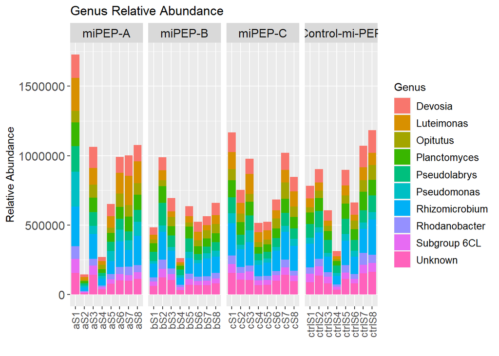

```r
################# GENUS #######################

pseq_soil_genus <- phylo_soil %>% aggregate_taxa(level = "Genus")
#ps1._soil_genus_top10 <- microbiome::aggregate_top_taxa(pseq_soil_genus, "Genus", top = 10)

ps1._soil_genus_top10 <- names(sort(taxa_sums(pseq_soil_genus), decreasing = TRUE))[1:10]
ps1._soil_genus_top10 <- prune_taxa(ps1._soil_genus_top10, pseq_soil_genus)

taxa_abundance_table_genus_soil <- psmelt(ps1._soil_genus_top10)

StackedBarPlot_genus_soil <- taxa_abundance_table_genus_soil %>%
  ggplot(aes(x =Sample, y = Abundance, fill = Genus)) +
  geom_bar(stat = "identity") +
  labs(x = "",
       y = "Relative Abundance",
       title = "Genus Relative Abundance") +
  facet_grid(~ Type, scales = "free") +
  theme(
    axis.text.x = element_text(size = 10, angle = 90, vjust = 0.5, hjust = 1),
    axis.text.y = element_text(size = 12),
    legend.text = element_text(size = 10),
    strip.text = element_text(size = 12)
  )

StackedBarPlot_genus_soil
```

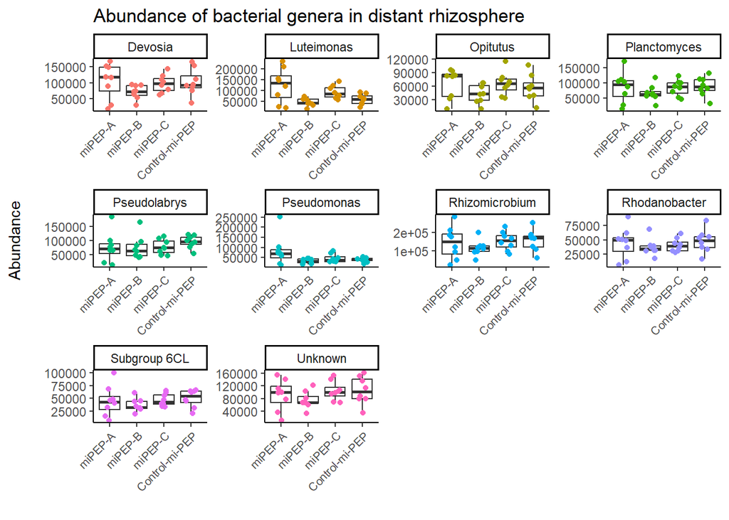

```r
#Boxplot

phyloseq::psmelt(ps1._soil_genus_top10) %>%
ggplot(data = ., aes(x = Type, y = Abundance)) +
  geom_boxplot(outlier.shape  = NA) +
  geom_jitter(aes(color = OTU), height = 0, width = .2) +
  labs(x = "", y = "Abundance\n") +
  facet_wrap(~ OTU, scales = "free") + guides(col = FALSE) +theme_classic() +theme(axis.text.x=element_text(size=8, angle=45,hjust=1)) + ggtitle(label = "Abundance of bacterial genera in distant rhizosphere")
```

Abudance plots (top phyla & genera) in unplanted samples

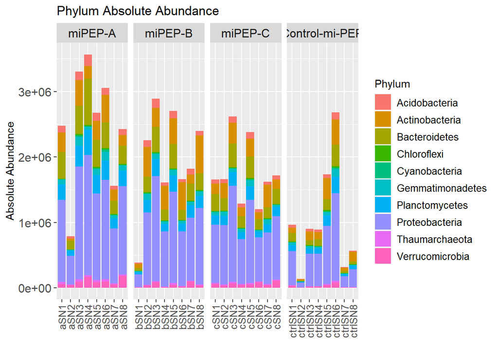

```r
pseq_unplanted <- phylo_unplanted %>% aggregate_taxa(level = "Phylum")
#ps1.com.fam_unplanted <- microbiome::aggregate_top_taxa(pseq_unplanted, "Phylum", top = 10)

ps1.com.fam_unplanted <- names(sort(taxa_sums(pseq_unplanted), decreasing = TRUE))[1:10]
ps1.com.fam_unplanted <- prune_taxa(ps1.com.fam_unplanted, pseq_unplanted)

taxa_abundance_table_phylum_unplanted <- psmelt(ps1.com.fam_unplanted)

StackedBarPlot_phylum <- taxa_abundance_table_phylum_unplanted %>%
  ggplot(aes(x =Sample, y = Abundance, fill = Phylum)) +
  geom_bar(stat = "identity") +
  labs(x = "",
       y = "Absolute Abundance",
       title = "Phylum Absolute Abundance") +
  facet_grid(~ Type, scales = "free") +
  theme(
    axis.text.x = element_text(size = 10, angle = 90, vjust = 0.5, hjust = 1),
    axis.text.y = element_text(size = 12),
    legend.text = element_text(size = 10),
    strip.text = element_text(size = 12)
  )
StackedBarPlot_phylum
```

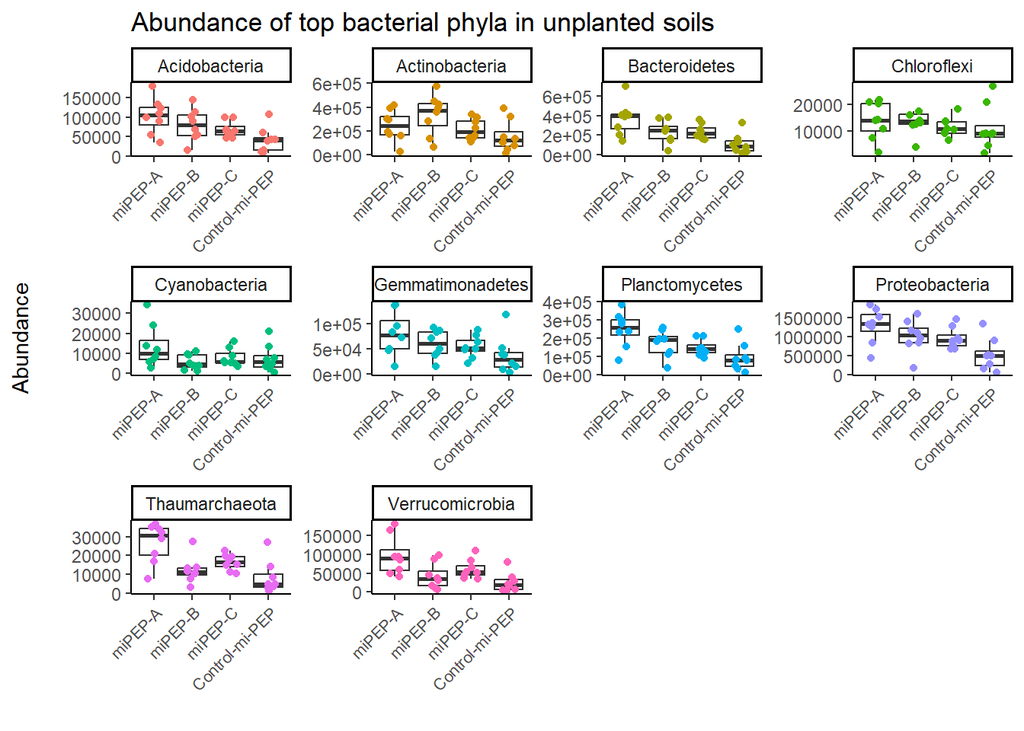

```r
#Create a boxplot to show differences in composition of each phylum per Type

phyloseq::psmelt(ps1.com.fam_unplanted) %>%
ggplot(data = ., aes(x = Type, y = Abundance)) +
  geom_boxplot(outlier.shape  = NA) +
  geom_jitter(aes(color = OTU), height = 0, width = .2) +
  labs(x = "", y = "Abundance\n") +
  facet_wrap(~ OTU, scales = "free") + guides(col = FALSE) +theme_classic() +theme(axis.text.x=element_text(size=8, angle=45,hjust=1)) + ggtitle(label = "Abundance of top bacterial phyla in unplanted soils")
```

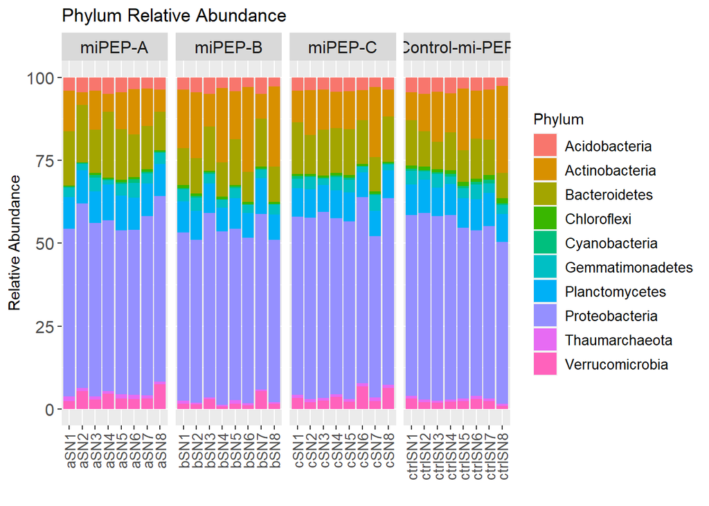

```r
# Transform Taxa counts to relative abundance for nice abundance plots
ps1_unplanted_phylum_relabun <- transform_sample_counts(ps1.com.fam_unplanted, function(OTU) OTU/sum(OTU) * 100)
taxa_abundance_table_phylum_unplanted_rel <- psmelt(ps1_unplanted_phylum_relabun)

StackedBarPlot_phylum_rel <- taxa_abundance_table_phylum_unplanted_rel %>%
  ggplot(aes(x =Sample, y = Abundance, fill = Phylum)) +
  geom_bar(stat = "identity") +
  labs(x = "",
       y = "Relative Abundance",
       title = "Phylum Relative Abundance") +
  facet_grid(~ Type, scales = "free") +
  theme(
    axis.text.x = element_text(size = 10, angle = 90, vjust = 0.5, hjust = 1),
    axis.text.y = element_text(size = 12),
    legend.text = element_text(size = 10),
    strip.text = element_text(size = 12)
  )
StackedBarPlot_phylum_rel
```

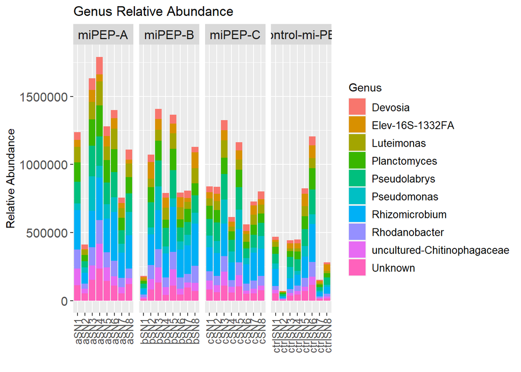

```r
#################### GENUS #####################

pseq_unplanted_genus <- phylo_unplanted %>% aggregate_taxa(level = "Genus")
#ps1._unplanted_genus_top10 <- microbiome::aggregate_top_taxa(pseq_unplanted_genus, "Genus", top = 10)

ps1._unplanted_genus_top10 <- names(sort(taxa_sums(pseq_unplanted_genus), decreasing = TRUE))[1:10]
ps1._unplanted_genus_top10 <- prune_taxa(ps1._unplanted_genus_top10, pseq_unplanted_genus)

taxa_abundance_table_genus_unplanted <- psmelt(ps1._unplanted_genus_top10)

StackedBarPlot_genus_unplanted <- taxa_abundance_table_genus_unplanted %>%
  ggplot(aes(x =Sample, y = Abundance, fill = Genus)) +
  geom_bar(stat = "identity") +
  labs(x = "",
       y = "Relative Abundance",
       title = "Genus Relative Abundance") +
  facet_grid(~ Type, scales = "free") +
  theme(
    axis.text.x = element_text(size = 10, angle = 90, vjust = 0.5, hjust = 1),
    axis.text.y = element_text(size = 12),
    legend.text = element_text(size = 10),
    strip.text = element_text(size = 12)
  )

StackedBarPlot_genus_unplanted
```

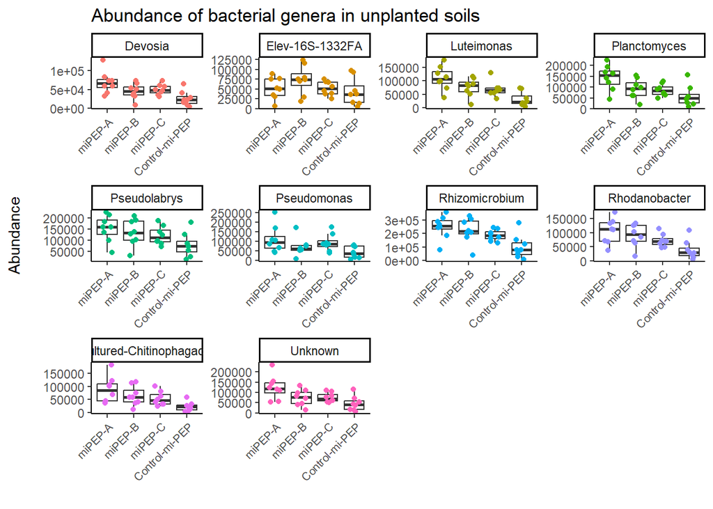

```r
#Boxplot

phyloseq::psmelt(ps1._unplanted_genus_top10) %>%
ggplot(data = ., aes(x = Type, y = Abundance)) +
  geom_boxplot(outlier.shape  = NA) +
  geom_jitter(aes(color = OTU), height = 0, width = .2) +
  labs(x = "", y = "Abundance\n") +
  facet_wrap(~ OTU, scales = "free") + guides(col = FALSE) +theme_classic() +theme(axis.text.x=element_text(size=8, angle=45,hjust=1)) + ggtitle(label = "Abundance of bacterial genera in unplanted soils")
```

What is the diversity within samples like? –> calculate alpha-diversity

The following is much inspired by https://www.nicholas-ollberding.com/post/introduction-to-the-statistical-analysis-of-microbiome-data-in-r/

The measurement of alpha-diversity is never 100% accurate, as (1) richness is always underestimated due to inexhaustive sampling and (2) rare taxa cannot be accounted for, as with NGS, singletons are eliminated from the beginning, as they could be just sequencing errors. In order to compare the index between samples (they will have similar error rates) and so that sequencing depth doesn’t interfere, it is recommended to rarefy the data. Rarefaction is the subsampling of your reads without replacement to a same sequencing depth (=number of reads).

Before rarefying, plotting Total Reads VS Observed Richness can be interesting. It seems logical that the more reads in a sample, the more potential diversity can be observed.

In the following paragraphs, the term “reads” is used, but it is really referring to “copies”, as reads have been converted to copies, in the otu_biom.

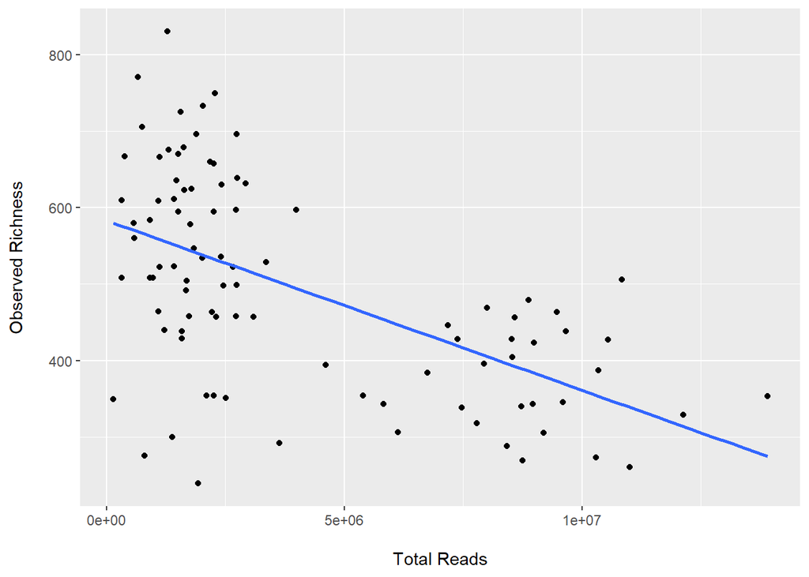

```r
ggplot(data = data.frame("total_reads" =  phyloseq::sample_sums(phylo_abs_16S),
"observed" = phyloseq::estimate_richness(phylo_abs_16S, measures = "Observed")[, 1]),
aes(x = total_reads, y = observed)) + geom_point() + geom_smooth(method="lm", se = FALSE)+ labs(x = "\nTotal Reads", y = "Observed Richness\n")
```

[output not shown]

[output not shown]

[output not shown]

[output not shown]

[output not shown]

[output not shown]

[output not shown]

[output not shown]

[output not shown]

[output not shown]

[output not shown]

[output not shown]

[output not shown]

[output not shown]

[output not shown]

[output not shown]

[output not shown]

[output not shown]

[output not shown]

[output not shown]

[output not shown]

[output not shown]

[output not shown]

[output not shown]

[output not shown]

[output not shown]

[output not shown]

[output not shown]

[output not shown]

[output not shown]

[output not shown]

[output not shown]

[output not shown]

[output not shown]

[output not shown]

[output not shown]

[output not shown]

[output not shown]

[output not shown]

[output not shown]

[output not shown]

[output not shown]

[output not shown]

[output not shown]

[output not shown]

[output not shown]

[output not shown]

[output not shown]

[output not shown]

[output not shown]

[output not shown]

[output not shown]

[output not shown]

[output not shown]

[output not shown]

[output not shown]

[output not shown]

[output not shown]

[output not shown]

[output not shown]

[output not shown]

[output not shown]

[output not shown]

[output not shown]

[output not shown]

[output not shown]

[output not shown]

[output not shown]

[output not shown]

[output not shown]

[output not shown]

[output not shown]

[output not shown]

[output not shown]

[output not shown]

[output not shown]

[output not shown]

[output not shown]

[output not shown]

[output not shown]

[output not shown]

[output not shown]

[output not shown]

[output not shown]

[output not shown]

[output not shown]

[output not shown]

[output not shown]

[output not shown]

[output not shown]

[output not shown]

[output not shown]

[output not shown]

[output not shown]

[output not shown]

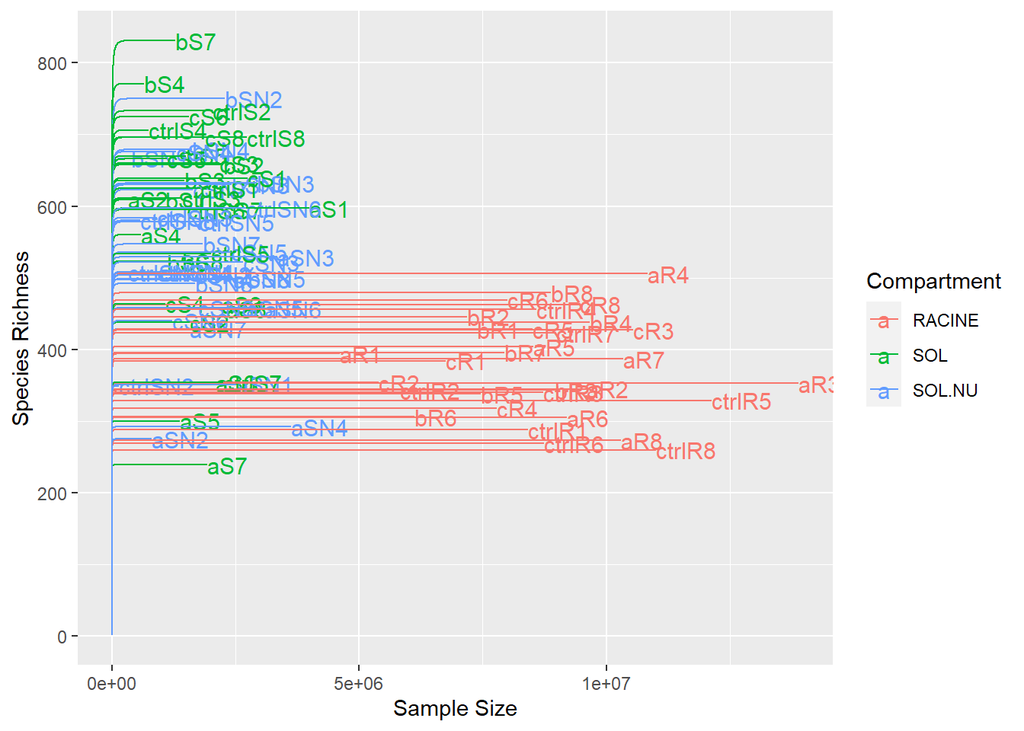

```r
#Draw the rarefaction curve for phylo_abs_16S

#remotes::install_github("mahendra-mariadassou/phyloseq-extended", ref = "dev")
library(phyloseq.extended)

p<-ggrare(phylo_abs_16S, step=100, color = "Compartment", label = "X.SampleID", se = FALSE)
```